# Risk Factor Analysis

## Outcome Variable

**Outcome Variable:** stunted

## Predictor Variables

**Intervention Variable:** vagbrth

**Adjustment Set:**

unadjusted

## Stratifying Variables

The analysis was stratified on these variable(s):

- agecat
- studyid
- country

## Data Summary

| agecat | studyid | country | A | n | nA | nAY0 | nAY1 |
| --- | --- | --- | --- | --- | --- | --- | --- |
| Birth | ki1000108-CMC-V-BCS-2002 | INDIA | 0 | 90 | 11 | 9 | 2 |
| Birth | ki1000108-CMC-V-BCS-2002 | INDIA | 1 | 90 | 79 | 65 | 14 |
| Birth | ki1000108-IRC | INDIA | 0 | 388 | 68 | 58 | 10 |
| Birth | ki1000108-IRC | INDIA | 1 | 388 | 320 | 285 | 35 |
| Birth | ki1017093c-NIH-Crypto | BANGLADESH | 0 | 19 | 1 | 1 | 0 |
| Birth | ki1017093c-NIH-Crypto | BANGLADESH | 1 | 19 | 18 | 15 | 3 |
| Birth | ki1126311-ZVITAMBO | ZIMBABWE | 0 | 13716 | 1162 | 1073 | 89 |
| Birth | ki1126311-ZVITAMBO | ZIMBABWE | 1 | 13716 | 12554 | 11233 | 1321 |
| 3 months | ki1000108-CMC-V-BCS-2002 | INDIA | 0 | 362 | 25 | 20 | 5 |
| 3 months | ki1000108-CMC-V-BCS-2002 | INDIA | 1 | 362 | 337 | 252 | 85 |
| 3 months | ki1000108-IRC | INDIA | 0 | 407 | 69 | 51 | 18 |
| 3 months | ki1000108-IRC | INDIA | 1 | 407 | 338 | 265 | 73 |
| 3 months | ki1017093b-PROVIDE | BANGLADESH | 0 | 645 | 150 | 136 | 14 |
| 3 months | ki1017093b-PROVIDE | BANGLADESH | 1 | 645 | 495 | 431 | 64 |
| 3 months | ki1017093c-NIH-Crypto | BANGLADESH | 0 | 471 | 193 | 159 | 34 |
| 3 months | ki1017093c-NIH-Crypto | BANGLADESH | 1 | 471 | 278 | 215 | 63 |
| 3 months | ki1066203-TanzaniaChild2 | TANZANIA, UNITED REPUBLIC OF | 0 | 2265 | 201 | 188 | 13 |
| 3 months | ki1066203-TanzaniaChild2 | TANZANIA, UNITED REPUBLIC OF | 1 | 2265 | 2064 | 1940 | 124 |
| 3 months | ki1126311-ZVITAMBO | ZIMBABWE | 0 | 9123 | 797 | 663 | 134 |
| 3 months | ki1126311-ZVITAMBO | ZIMBABWE | 1 | 9123 | 8326 | 6834 | 1492 |
| 6 months | ki1000108-CMC-V-BCS-2002 | INDIA | 0 | 369 | 25 | 17 | 8 |
| 6 months | ki1000108-CMC-V-BCS-2002 | INDIA | 1 | 369 | 344 | 241 | 103 |
| 6 months | ki1000108-IRC | INDIA | 0 | 407 | 69 | 50 | 19 |
| 6 months | ki1000108-IRC | INDIA | 1 | 407 | 338 | 257 | 81 |
| 6 months | ki1017093b-PROVIDE | BANGLADESH | 0 | 583 | 134 | 112 | 22 |
| 6 months | ki1017093b-PROVIDE | BANGLADESH | 1 | 583 | 449 | 377 | 72 |
| 6 months | ki1017093c-NIH-Crypto | BANGLADESH | 0 | 457 | 187 | 151 | 36 |
| 6 months | ki1017093c-NIH-Crypto | BANGLADESH | 1 | 457 | 270 | 198 | 72 |
| 6 months | ki1066203-TanzaniaChild2 | TANZANIA, UNITED REPUBLIC OF | 0 | 2005 | 189 | 172 | 17 |
| 6 months | ki1066203-TanzaniaChild2 | TANZANIA, UNITED REPUBLIC OF | 1 | 2005 | 1816 | 1636 | 180 |
| 6 months | ki1126311-ZVITAMBO | ZIMBABWE | 0 | 8228 | 707 | 597 | 110 |
| 6 months | ki1126311-ZVITAMBO | ZIMBABWE | 1 | 8228 | 7521 | 6259 | 1262 |
| 9 months | ki1000108-CMC-V-BCS-2002 | INDIA | 0 | 366 | 24 | 12 | 12 |
| 9 months | ki1000108-CMC-V-BCS-2002 | INDIA | 1 | 366 | 342 | 219 | 123 |
| 9 months | ki1000108-IRC | INDIA | 0 | 407 | 69 | 53 | 16 |
| 9 months | ki1000108-IRC | INDIA | 1 | 407 | 338 | 243 | 95 |
| 9 months | ki1017093b-PROVIDE | BANGLADESH | 0 | 605 | 139 | 118 | 21 |
| 9 months | ki1017093b-PROVIDE | BANGLADESH | 1 | 605 | 466 | 358 | 108 |
| 9 months | ki1017093c-NIH-Crypto | BANGLADESH | 0 | 450 | 185 | 151 | 34 |
| 9 months | ki1017093c-NIH-Crypto | BANGLADESH | 1 | 450 | 265 | 194 | 71 |
| 9 months | ki1066203-TanzaniaChild2 | TANZANIA, UNITED REPUBLIC OF | 0 | 1770 | 168 | 152 | 16 |
| 9 months | ki1066203-TanzaniaChild2 | TANZANIA, UNITED REPUBLIC OF | 1 | 1770 | 1602 | 1354 | 248 |
| 9 months | ki1126311-ZVITAMBO | ZIMBABWE | 0 | 7609 | 640 | 517 | 123 |
| 9 months | ki1126311-ZVITAMBO | ZIMBABWE | 1 | 7609 | 6969 | 5589 | 1380 |
| 12 months | ki1000108-CMC-V-BCS-2002 | INDIA | 0 | 368 | 25 | 11 | 14 |
| 12 months | ki1000108-CMC-V-BCS-2002 | INDIA | 1 | 368 | 343 | 174 | 169 |
| 12 months | ki1000108-IRC | INDIA | 0 | 406 | 70 | 51 | 19 |
| 12 months | ki1000108-IRC | INDIA | 1 | 406 | 336 | 236 | 100 |
| 12 months | ki1017093b-PROVIDE | BANGLADESH | 0 | 600 | 138 | 112 | 26 |
| 12 months | ki1017093b-PROVIDE | BANGLADESH | 1 | 600 | 462 | 331 | 131 |
| 12 months | ki1017093c-NIH-Crypto | BANGLADESH | 0 | 450 | 185 | 147 | 38 |
| 12 months | ki1017093c-NIH-Crypto | BANGLADESH | 1 | 450 | 265 | 186 | 79 |
| 12 months | ki1066203-TanzaniaChild2 | TANZANIA, UNITED REPUBLIC OF | 0 | 1424 | 137 | 123 | 14 |
| 12 months | ki1066203-TanzaniaChild2 | TANZANIA, UNITED REPUBLIC OF | 1 | 1424 | 1287 | 1064 | 223 |
| 12 months | ki1126311-ZVITAMBO | ZIMBABWE | 0 | 6691 | 550 | 412 | 138 |
| 12 months | ki1126311-ZVITAMBO | ZIMBABWE | 1 | 6691 | 6141 | 4646 | 1495 |
| 18 months | ki1000108-CMC-V-BCS-2002 | INDIA | 0 | 369 | 25 | 7 | 18 |
| 18 months | ki1000108-CMC-V-BCS-2002 | INDIA | 1 | 369 | 344 | 108 | 236 |
| 18 months | ki1000108-IRC | INDIA | 0 | 405 | 69 | 44 | 25 |
| 18 months | ki1000108-IRC | INDIA | 1 | 405 | 336 | 217 | 119 |
| 18 months | ki1017093b-PROVIDE | BANGLADESH | 0 | 552 | 129 | 90 | 39 |
| 18 months | ki1017093b-PROVIDE | BANGLADESH | 1 | 552 | 423 | 256 | 167 |
| 18 months | ki1017093c-NIH-Crypto | BANGLADESH | 0 | 380 | 150 | 109 | 41 |
| 18 months | ki1017093c-NIH-Crypto | BANGLADESH | 1 | 380 | 230 | 140 | 90 |
| 18 months | ki1066203-TanzaniaChild2 | TANZANIA, UNITED REPUBLIC OF | 0 | 967 | 89 | 74 | 15 |
| 18 months | ki1066203-TanzaniaChild2 | TANZANIA, UNITED REPUBLIC OF | 1 | 967 | 878 | 661 | 217 |
| 18 months | ki1126311-ZVITAMBO | ZIMBABWE | 0 | 1692 | 141 | 80 | 61 |
| 18 months | ki1126311-ZVITAMBO | ZIMBABWE | 1 | 1692 | 1551 | 806 | 745 |
| 24 months | ki1000108-CMC-V-BCS-2002 | INDIA | 0 | 372 | 25 | 8 | 17 |
| 24 months | ki1000108-CMC-V-BCS-2002 | INDIA | 1 | 372 | 347 | 98 | 249 |
| 24 months | ki1000108-IRC | INDIA | 0 | 409 | 69 | 42 | 27 |
| 24 months | ki1000108-IRC | INDIA | 1 | 409 | 340 | 197 | 143 |
| 24 months | ki1017093b-PROVIDE | BANGLADESH | 0 | 577 | 137 | 99 | 38 |
| 24 months | ki1017093b-PROVIDE | BANGLADESH | 1 | 577 | 440 | 288 | 152 |
| 24 months | ki1017093c-NIH-Crypto | BANGLADESH | 0 | 260 | 99 | 75 | 24 |
| 24 months | ki1017093c-NIH-Crypto | BANGLADESH | 1 | 260 | 161 | 104 | 57 |
| 24 months | ki1066203-TanzaniaChild2 | TANZANIA, UNITED REPUBLIC OF | 0 | 6 | 2 | 2 | 0 |
| 24 months | ki1066203-TanzaniaChild2 | TANZANIA, UNITED REPUBLIC OF | 1 | 6 | 4 | 3 | 1 |
| 24 months | ki1126311-ZVITAMBO | ZIMBABWE | 0 | 450 | 29 | 11 | 18 |
| 24 months | ki1126311-ZVITAMBO | ZIMBABWE | 1 | 450 | 421 | 145 | 276 |

The following strata were considered:

- agecat: 12 months, studyid: ki1000108-CMC-V-BCS-2002, country: INDIA
- agecat: 12 months, studyid: ki1000108-IRC, country: INDIA
- agecat: 12 months, studyid: ki1017093b-PROVIDE, country: BANGLADESH
- agecat: 12 months, studyid: ki1017093c-NIH-Crypto, country: BANGLADESH
- agecat: 12 months, studyid: ki1066203-TanzaniaChild2, country: TANZANIA, UNITED REPUBLIC OF
- agecat: 12 months, studyid: ki1126311-ZVITAMBO, country: ZIMBABWE
- agecat: 18 months, studyid: ki1000108-CMC-V-BCS-2002, country: INDIA
- agecat: 18 months, studyid: ki1000108-IRC, country: INDIA
- agecat: 18 months, studyid: ki1017093b-PROVIDE, country: BANGLADESH
- agecat: 18 months, studyid: ki1017093c-NIH-Crypto, country: BANGLADESH
- agecat: 18 months, studyid: ki1066203-TanzaniaChild2, country: TANZANIA, UNITED REPUBLIC OF
- agecat: 18 months, studyid: ki1126311-ZVITAMBO, country: ZIMBABWE
- agecat: 24 months, studyid: ki1000108-CMC-V-BCS-2002, country: INDIA
- agecat: 24 months, studyid: ki1000108-IRC, country: INDIA
- agecat: 24 months, studyid: ki1017093b-PROVIDE, country: BANGLADESH
- agecat: 24 months, studyid: ki1017093c-NIH-Crypto, country: BANGLADESH
- agecat: 24 months, studyid: ki1066203-TanzaniaChild2, country: TANZANIA, UNITED REPUBLIC OF
- agecat: 24 months, studyid: ki1126311-ZVITAMBO, country: ZIMBABWE
- agecat: 3 months, studyid: ki1000108-CMC-V-BCS-2002, country: INDIA
- agecat: 3 months, studyid: ki1000108-IRC, country: INDIA
- agecat: 3 months, studyid: ki1017093b-PROVIDE, country: BANGLADESH
- agecat: 3 months, studyid: ki1017093c-NIH-Crypto, country: BANGLADESH
- agecat: 3 months, studyid: ki1066203-TanzaniaChild2, country: TANZANIA, UNITED REPUBLIC OF
- agecat: 3 months, studyid: ki1126311-ZVITAMBO, country: ZIMBABWE
- agecat: 6 months, studyid: ki1000108-CMC-V-BCS-2002, country: INDIA
- agecat: 6 months, studyid: ki1000108-IRC, country: INDIA
- agecat: 6 months, studyid: ki1017093b-PROVIDE, country: BANGLADESH
- agecat: 6 months, studyid: ki1017093c-NIH-Crypto, country: BANGLADESH
- agecat: 6 months, studyid: ki1066203-TanzaniaChild2, country: TANZANIA, UNITED REPUBLIC OF
- agecat: 6 months, studyid: ki1126311-ZVITAMBO, country: ZIMBABWE
- agecat: 9 months, studyid: ki1000108-CMC-V-BCS-2002, country: INDIA
- agecat: 9 months, studyid: ki1000108-IRC, country: INDIA
- agecat: 9 months, studyid: ki1017093b-PROVIDE, country: BANGLADESH
- agecat: 9 months, studyid: ki1017093c-NIH-Crypto, country: BANGLADESH
- agecat: 9 months, studyid: ki1066203-TanzaniaChild2, country: TANZANIA, UNITED REPUBLIC OF
- agecat: 9 months, studyid: ki1126311-ZVITAMBO, country: ZIMBABWE
- agecat: Birth, studyid: ki1000108-CMC-V-BCS-2002, country: INDIA
- agecat: Birth, studyid: ki1000108-IRC, country: INDIA
- agecat: Birth, studyid: ki1017093c-NIH-Crypto, country: BANGLADESH
- agecat: Birth, studyid: ki1126311-ZVITAMBO, country: ZIMBABWE

### Dropped Strata

Some strata were dropped due to rare outcomes:

- agecat: Birth, studyid: ki1000108-CMC-V-BCS-2002, country: INDIA
- agecat: Birth, studyid: ki1017093c-NIH-Crypto, country: BANGLADESH
- agecat: 24 months, studyid: ki1066203-TanzaniaChild2, country: TANZANIA, UNITED REPUBLIC OF

## Methods Detail

We’re interested in the causal parameters $E[Y_a]$ for all values of $a \in \mathcal{A}$. These parameters represent the mean outcome if, possibly contrary to fact, we intervened to set all units to have $A=a$. Under the randomization and positivity assumptions, these are identified by the statistical parameters $\psi_a=E_W[E_{Y|A,W}(Y|A=a,W)]$. In addition, we’re interested in the mean of $Y$, $E[Y]$ under no intervention (the observed mean). We will estimate these parameters by using SuperLearner to fit the relevant likelihood factors – $E_{Y|A,W}(Y|A=a,W)$ and $p(A=a|W)$, and then updating our likelihood fit using a joint TMLE.

For unadjusted analyses ($W=\{\}$), initial likelihoods were estimated using Lrnr_glm to estimate the simple $E(Y|A)$ and Lrnr_mean to estimate $p(A)$. For adjusted analyses, a small library containing Lrnr_glmnet, Lrnr_xgboost, and Lrnr_mean was used.

Having estimated these parameters, we will then use the delta method to estimate relative risks and attributable risks relative to a prespecified baseline level of $A$.

# Results Detail

## Results Plots

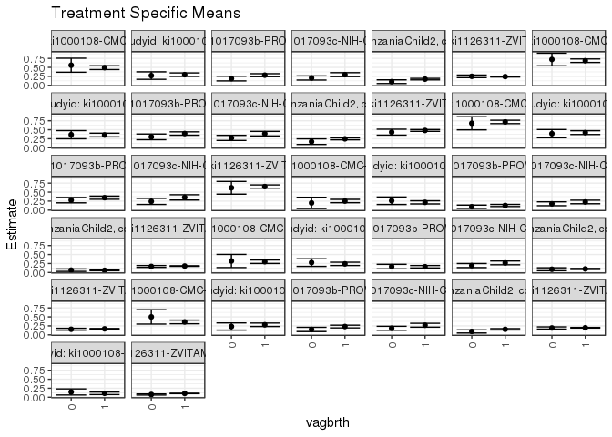

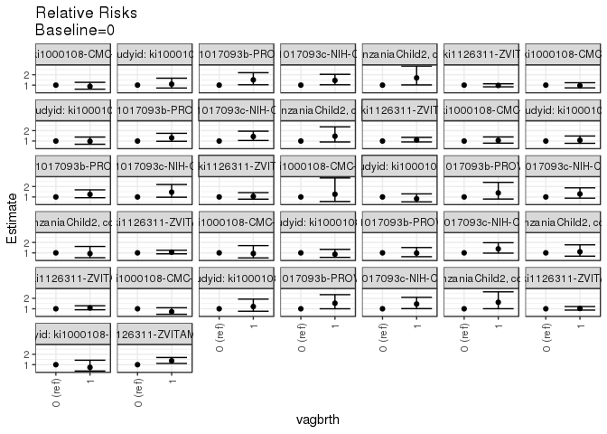

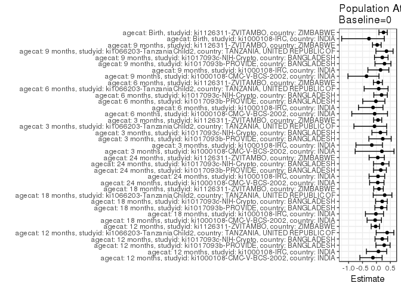

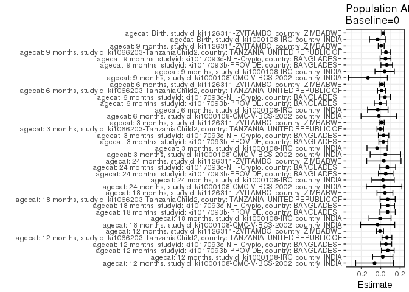

## Results Table

### Parameter: TSM

| agecat | studyid | country | intervention_level | baseline_level | estimate | ci_lower | ci_upper |
| --- | --- | --- | --- | --- | --- | --- | --- |
| Birth | ki1000108-IRC | INDIA | 0 | NA | 0.1470588 | 0.0627721 | 0.2313455 |
| Birth | ki1000108-IRC | INDIA | 1 | NA | 0.1093750 | 0.0751345 | 0.1436155 |
| Birth | ki1126311-ZVITAMBO | ZIMBABWE | 0 | NA | 0.0765921 | 0.0613006 | 0.0918836 |
| Birth | ki1126311-ZVITAMBO | ZIMBABWE | 1 | NA | 0.1052254 | 0.0998577 | 0.1105931 |
| 3 months | ki1000108-CMC-V-BCS-2002 | INDIA | 0 | NA | 0.2000000 | 0.0429859 | 0.3570141 |
| 3 months | ki1000108-CMC-V-BCS-2002 | INDIA | 1 | NA | 0.2522255 | 0.2057939 | 0.2986571 |
| 3 months | ki1000108-IRC | INDIA | 0 | NA | 0.2608696 | 0.1571334 | 0.3646057 |
| 3 months | ki1000108-IRC | INDIA | 1 | NA | 0.2159763 | 0.1720534 | 0.2598993 |
| 3 months | ki1017093b-PROVIDE | BANGLADESH | 0 | NA | 0.0933333 | 0.0467445 | 0.1399221 |
| 3 months | ki1017093b-PROVIDE | BANGLADESH | 1 | NA | 0.1292929 | 0.0997124 | 0.1588735 |
| 3 months | ki1017093c-NIH-Crypto | BANGLADESH | 0 | NA | 0.1761658 | 0.1223622 | 0.2299694 |
| 3 months | ki1017093c-NIH-Crypto | BANGLADESH | 1 | NA | 0.2266187 | 0.1773544 | 0.2758830 |
| 3 months | ki1066203-TanzaniaChild2 | TANZANIA, UNITED REPUBLIC OF | 0 | NA | 0.0646766 | 0.0306671 | 0.0986861 |
| 3 months | ki1066203-TanzaniaChild2 | TANZANIA, UNITED REPUBLIC OF | 1 | NA | 0.0600775 | 0.0498236 | 0.0703315 |
| 3 months | ki1126311-ZVITAMBO | ZIMBABWE | 0 | NA | 0.1681305 | 0.1421652 | 0.1940958 |
| 3 months | ki1126311-ZVITAMBO | ZIMBABWE | 1 | NA | 0.1791977 | 0.1709594 | 0.1874360 |
| 6 months | ki1000108-CMC-V-BCS-2002 | INDIA | 0 | NA | 0.3200000 | 0.1368964 | 0.5031036 |
| 6 months | ki1000108-CMC-V-BCS-2002 | INDIA | 1 | NA | 0.2994186 | 0.2509538 | 0.3478835 |
| 6 months | ki1000108-IRC | INDIA | 0 | NA | 0.2753623 | 0.1698337 | 0.3808910 |
| 6 months | ki1000108-IRC | INDIA | 1 | NA | 0.2396450 | 0.1940816 | 0.2852084 |
| 6 months | ki1017093b-PROVIDE | BANGLADESH | 0 | NA | 0.1641791 | 0.1014045 | 0.2269537 |
| 6 months | ki1017093b-PROVIDE | BANGLADESH | 1 | NA | 0.1603563 | 0.1263869 | 0.1943258 |
| 6 months | ki1017093c-NIH-Crypto | BANGLADESH | 0 | NA | 0.1925134 | 0.1359414 | 0.2490853 |
| 6 months | ki1017093c-NIH-Crypto | BANGLADESH | 1 | NA | 0.2666667 | 0.2138614 | 0.3194719 |
| 6 months | ki1066203-TanzaniaChild2 | TANZANIA, UNITED REPUBLIC OF | 0 | NA | 0.0899471 | 0.0491478 | 0.1307464 |
| 6 months | ki1066203-TanzaniaChild2 | TANZANIA, UNITED REPUBLIC OF | 1 | NA | 0.0991189 | 0.0853719 | 0.1128660 |
| 6 months | ki1126311-ZVITAMBO | ZIMBABWE | 0 | NA | 0.1555870 | 0.1288675 | 0.1823065 |
| 6 months | ki1126311-ZVITAMBO | ZIMBABWE | 1 | NA | 0.1677968 | 0.1593510 | 0.1762427 |
| 9 months | ki1000108-CMC-V-BCS-2002 | INDIA | 0 | NA | 0.5000000 | 0.2996882 | 0.7003118 |
| 9 months | ki1000108-CMC-V-BCS-2002 | INDIA | 1 | NA | 0.3596491 | 0.3087187 | 0.4105796 |
| 9 months | ki1000108-IRC | INDIA | 0 | NA | 0.2318841 | 0.1321814 | 0.3315867 |
| 9 months | ki1000108-IRC | INDIA | 1 | NA | 0.2810651 | 0.2330838 | 0.3290464 |
| 9 months | ki1017093b-PROVIDE | BANGLADESH | 0 | NA | 0.1510791 | 0.0914943 | 0.2106640 |
| 9 months | ki1017093b-PROVIDE | BANGLADESH | 1 | NA | 0.2317597 | 0.1934170 | 0.2701023 |
| 9 months | ki1017093c-NIH-Crypto | BANGLADESH | 0 | NA | 0.1837838 | 0.1279108 | 0.2396567 |
| 9 months | ki1017093c-NIH-Crypto | BANGLADESH | 1 | NA | 0.2679245 | 0.2145428 | 0.3213062 |
| 9 months | ki1066203-TanzaniaChild2 | TANZANIA, UNITED REPUBLIC OF | 0 | NA | 0.0952381 | 0.0508375 | 0.1396387 |
| 9 months | ki1066203-TanzaniaChild2 | TANZANIA, UNITED REPUBLIC OF | 1 | NA | 0.1548065 | 0.1370886 | 0.1725244 |
| 9 months | ki1126311-ZVITAMBO | ZIMBABWE | 0 | NA | 0.1921875 | 0.1616591 | 0.2227159 |
| 9 months | ki1126311-ZVITAMBO | ZIMBABWE | 1 | NA | 0.1980198 | 0.1886630 | 0.2073766 |
| 12 months | ki1000108-CMC-V-BCS-2002 | INDIA | 0 | NA | 0.5600000 | 0.3651550 | 0.7548450 |
| 12 months | ki1000108-CMC-V-BCS-2002 | INDIA | 1 | NA | 0.4927114 | 0.4397309 | 0.5456918 |
| 12 months | ki1000108-IRC | INDIA | 0 | NA | 0.2714286 | 0.1671252 | 0.3757320 |
| 12 months | ki1000108-IRC | INDIA | 1 | NA | 0.2976190 | 0.2486715 | 0.3465666 |
| 12 months | ki1017093b-PROVIDE | BANGLADESH | 0 | NA | 0.1884058 | 0.1231097 | 0.2537019 |
| 12 months | ki1017093b-PROVIDE | BANGLADESH | 1 | NA | 0.2835498 | 0.2424162 | 0.3246834 |
| 12 months | ki1017093c-NIH-Crypto | BANGLADESH | 0 | NA | 0.2054054 | 0.1471248 | 0.2636860 |
| 12 months | ki1017093c-NIH-Crypto | BANGLADESH | 1 | NA | 0.2981132 | 0.2429776 | 0.3532488 |
| 12 months | ki1066203-TanzaniaChild2 | TANZANIA, UNITED REPUBLIC OF | 0 | NA | 0.1021898 | 0.0514514 | 0.1529281 |
| 12 months | ki1066203-TanzaniaChild2 | TANZANIA, UNITED REPUBLIC OF | 1 | NA | 0.1732712 | 0.1525861 | 0.1939562 |
| 12 months | ki1126311-ZVITAMBO | ZIMBABWE | 0 | NA | 0.2509091 | 0.2146744 | 0.2871438 |
| 12 months | ki1126311-ZVITAMBO | ZIMBABWE | 1 | NA | 0.2434457 | 0.2327112 | 0.2541802 |
| 18 months | ki1000108-CMC-V-BCS-2002 | INDIA | 0 | NA | 0.7200000 | 0.5437567 | 0.8962433 |
| 18 months | ki1000108-CMC-V-BCS-2002 | INDIA | 1 | NA | 0.6860465 | 0.6369368 | 0.7351562 |
| 18 months | ki1000108-IRC | INDIA | 0 | NA | 0.3623188 | 0.2487635 | 0.4758742 |
| 18 months | ki1000108-IRC | INDIA | 1 | NA | 0.3541667 | 0.3029656 | 0.4053678 |
| 18 months | ki1017093b-PROVIDE | BANGLADESH | 0 | NA | 0.3023256 | 0.2230004 | 0.3816507 |
| 18 months | ki1017093b-PROVIDE | BANGLADESH | 1 | NA | 0.3947991 | 0.3481751 | 0.4414231 |
| 18 months | ki1017093c-NIH-Crypto | BANGLADESH | 0 | NA | 0.2733333 | 0.2019185 | 0.3447482 |
| 18 months | ki1017093c-NIH-Crypto | BANGLADESH | 1 | NA | 0.3913043 | 0.3281485 | 0.4544602 |
| 18 months | ki1066203-TanzaniaChild2 | TANZANIA, UNITED REPUBLIC OF | 0 | NA | 0.1685393 | 0.0907268 | 0.2463518 |
| 18 months | ki1066203-TanzaniaChild2 | TANZANIA, UNITED REPUBLIC OF | 1 | NA | 0.2471526 | 0.2186055 | 0.2756997 |
| 18 months | ki1126311-ZVITAMBO | ZIMBABWE | 0 | NA | 0.4326241 | 0.3508233 | 0.5144249 |
| 18 months | ki1126311-ZVITAMBO | ZIMBABWE | 1 | NA | 0.4803353 | 0.4554636 | 0.5052069 |
| 24 months | ki1000108-CMC-V-BCS-2002 | INDIA | 0 | NA | 0.6800000 | 0.4968984 | 0.8631016 |
| 24 months | ki1000108-CMC-V-BCS-2002 | INDIA | 1 | NA | 0.7175793 | 0.6701495 | 0.7650090 |
| 24 months | ki1000108-IRC | INDIA | 0 | NA | 0.3913043 | 0.2760088 | 0.5065999 |
| 24 months | ki1000108-IRC | INDIA | 1 | NA | 0.4205882 | 0.3680516 | 0.4731249 |
| 24 months | ki1017093b-PROVIDE | BANGLADESH | 0 | NA | 0.2773723 | 0.2023391 | 0.3524054 |
| 24 months | ki1017093b-PROVIDE | BANGLADESH | 1 | NA | 0.3454545 | 0.3009849 | 0.3899242 |
| 24 months | ki1017093c-NIH-Crypto | BANGLADESH | 0 | NA | 0.2424242 | 0.1578441 | 0.3270044 |
| 24 months | ki1017093c-NIH-Crypto | BANGLADESH | 1 | NA | 0.3540373 | 0.2800256 | 0.4280489 |
| 24 months | ki1126311-ZVITAMBO | ZIMBABWE | 0 | NA | 0.6206897 | 0.4438960 | 0.7974834 |
| 24 months | ki1126311-ZVITAMBO | ZIMBABWE | 1 | NA | 0.6555819 | 0.6101411 | 0.7010228 |

### Parameter: E(Y)

| agecat | studyid | country | intervention_level | baseline_level | estimate | ci_lower | ci_upper |
| --- | --- | --- | --- | --- | --- | --- | --- |
| Birth | ki1000108-IRC | INDIA | NA | NA | 0.1159794 | 0.1145520 | 0.1174068 |
| Birth | ki1126311-ZVITAMBO | ZIMBABWE | NA | NA | 0.1027997 | 0.1026662 | 0.1029331 |
| 3 months | ki1000108-CMC-V-BCS-2002 | INDIA | NA | NA | 0.2486188 | 0.2472528 | 0.2499848 |
| 3 months | ki1000108-IRC | INDIA | NA | NA | 0.2235872 | 0.2219487 | 0.2252258 |
| 3 months | ki1017093b-PROVIDE | BANGLADESH | NA | NA | 0.1209302 | 0.1197569 | 0.1221035 |
| 3 months | ki1017093c-NIH-Crypto | BANGLADESH | NA | NA | 0.2059448 | 0.2037016 | 0.2081880 |
| 3 months | ki1066203-TanzaniaChild2 | TANZANIA, UNITED REPUBLIC OF | NA | NA | 0.0604857 | 0.0604318 | 0.0605395 |
| 3 months | ki1126311-ZVITAMBO | ZIMBABWE | NA | NA | 0.1782308 | 0.1781667 | 0.1782950 |
| 6 months | ki1000108-CMC-V-BCS-2002 | INDIA | NA | NA | 0.3008130 | 0.3002845 | 0.3013415 |
| 6 months | ki1000108-IRC | INDIA | NA | NA | 0.2457002 | 0.2443966 | 0.2470039 |
| 6 months | ki1017093b-PROVIDE | BANGLADESH | NA | NA | 0.1612350 | 0.1611043 | 0.1613657 |
| 6 months | ki1017093c-NIH-Crypto | BANGLADESH | NA | NA | 0.2363239 | 0.2329774 | 0.2396703 |
| 6 months | ki1066203-TanzaniaChild2 | TANZANIA, UNITED REPUBLIC OF | NA | NA | 0.0982544 | 0.0981370 | 0.0983717 |
| 6 months | ki1126311-ZVITAMBO | ZIMBABWE | NA | NA | 0.1667477 | 0.1666737 | 0.1668216 |
| 9 months | ki1000108-CMC-V-BCS-2002 | INDIA | NA | NA | 0.3688525 | 0.3652883 | 0.3724166 |
| 9 months | ki1000108-IRC | INDIA | NA | NA | 0.2727273 | 0.2709322 | 0.2745223 |
| 9 months | ki1017093b-PROVIDE | BANGLADESH | NA | NA | 0.2132231 | 0.2105164 | 0.2159299 |
| 9 months | ki1017093c-NIH-Crypto | BANGLADESH | NA | NA | 0.2333333 | 0.2295040 | 0.2371627 |
| 9 months | ki1066203-TanzaniaChild2 | TANZANIA, UNITED REPUBLIC OF | NA | NA | 0.1491525 | 0.1483389 | 0.1499661 |
| 9 months | ki1126311-ZVITAMBO | ZIMBABWE | NA | NA | 0.1975292 | 0.1974929 | 0.1975656 |
| 12 months | ki1000108-CMC-V-BCS-2002 | INDIA | NA | NA | 0.4972826 | 0.4955503 | 0.4990149 |
| 12 months | ki1000108-IRC | INDIA | NA | NA | 0.2931034 | 0.2921399 | 0.2940670 |
| 12 months | ki1017093b-PROVIDE | BANGLADESH | NA | NA | 0.2616667 | 0.2584602 | 0.2648731 |
| 12 months | ki1017093c-NIH-Crypto | BANGLADESH | NA | NA | 0.2600000 | 0.2557807 | 0.2642193 |
| 12 months | ki1066203-TanzaniaChild2 | TANZANIA, UNITED REPUBLIC OF | NA | NA | 0.1664326 | 0.1653436 | 0.1675216 |
| 12 months | ki1126311-ZVITAMBO | ZIMBABWE | NA | NA | 0.2440592 | 0.2440101 | 0.2441083 |
| 18 months | ki1000108-CMC-V-BCS-2002 | INDIA | NA | NA | 0.6883469 | 0.6874751 | 0.6892187 |
| 18 months | ki1000108-IRC | INDIA | NA | NA | 0.3555556 | 0.3552567 | 0.3558544 |
| 18 months | ki1017093b-PROVIDE | BANGLADESH | NA | NA | 0.3731884 | 0.3699209 | 0.3764559 |
| 18 months | ki1017093c-NIH-Crypto | BANGLADESH | NA | NA | 0.3447368 | 0.3389315 | 0.3505422 |
| 18 months | ki1066203-TanzaniaChild2 | TANZANIA, UNITED REPUBLIC OF | NA | NA | 0.2399173 | 0.2384842 | 0.2413504 |
| 18 months | ki1126311-ZVITAMBO | ZIMBABWE | NA | NA | 0.4763593 | 0.4757308 | 0.4769878 |
| 24 months | ki1000108-CMC-V-BCS-2002 | INDIA | NA | NA | 0.7150538 | 0.7140963 | 0.7160112 |
| 24 months | ki1000108-IRC | INDIA | NA | NA | 0.4156479 | 0.4145838 | 0.4167120 |
| 24 months | ki1017093b-PROVIDE | BANGLADESH | NA | NA | 0.3292894 | 0.3269236 | 0.3316552 |
| 24 months | ki1017093c-NIH-Crypto | BANGLADESH | NA | NA | 0.3115385 | 0.3049381 | 0.3181389 |
| 24 months | ki1126311-ZVITAMBO | ZIMBABWE | NA | NA | 0.6533333 | 0.6525409 | 0.6541258 |

### Parameter: RR

| agecat | studyid | country | intervention_level | baseline_level | estimate | ci_lower | ci_upper |
| --- | --- | --- | --- | --- | --- | --- | --- |
| Birth | ki1000108-IRC | INDIA | 0 | 0 | 1.0000000 | 1.0000000 | 1.000000 |
| Birth | ki1000108-IRC | INDIA | 1 | 0 | 0.7437500 | 0.3870802 | 1.429068 |
| Birth | ki1126311-ZVITAMBO | ZIMBABWE | 0 | 0 | 1.0000000 | 1.0000000 | 1.000000 |
| Birth | ki1126311-ZVITAMBO | ZIMBABWE | 1 | 0 | 1.3738421 | 1.1180085 | 1.688218 |
| 3 months | ki1000108-CMC-V-BCS-2002 | INDIA | 0 | 0 | 1.0000000 | 1.0000000 | 1.000000 |
| 3 months | ki1000108-CMC-V-BCS-2002 | INDIA | 1 | 0 | 1.2611276 | 0.5630659 | 2.824612 |
| 3 months | ki1000108-IRC | INDIA | 0 | 0 | 1.0000000 | 1.0000000 | 1.000000 |
| 3 months | ki1000108-IRC | INDIA | 1 | 0 | 0.8279093 | 0.5296742 | 1.294067 |
| 3 months | ki1017093b-PROVIDE | BANGLADESH | 0 | 0 | 1.0000000 | 1.0000000 | 1.000000 |
| 3 months | ki1017093b-PROVIDE | BANGLADESH | 1 | 0 | 1.3852813 | 0.7999581 | 2.398881 |
| 3 months | ki1017093c-NIH-Crypto | BANGLADESH | 0 | 0 | 1.0000000 | 1.0000000 | 1.000000 |
| 3 months | ki1017093c-NIH-Crypto | BANGLADESH | 1 | 0 | 1.2863944 | 0.8842302 | 1.871470 |
| 3 months | ki1066203-TanzaniaChild2 | TANZANIA, UNITED REPUBLIC OF | 0 | 0 | 1.0000000 | 1.0000000 | 1.000000 |
| 3 months | ki1066203-TanzaniaChild2 | TANZANIA, UNITED REPUBLIC OF | 1 | 0 | 0.9288909 | 0.5344005 | 1.614591 |
| 3 months | ki1126311-ZVITAMBO | ZIMBABWE | 0 | 0 | 1.0000000 | 1.0000000 | 1.000000 |
| 3 months | ki1126311-ZVITAMBO | ZIMBABWE | 1 | 0 | 1.0658251 | 0.9072077 | 1.252175 |
| 6 months | ki1000108-CMC-V-BCS-2002 | INDIA | 0 | 0 | 1.0000000 | 1.0000000 | 1.000000 |
| 6 months | ki1000108-CMC-V-BCS-2002 | INDIA | 1 | 0 | 0.9356831 | 0.5162674 | 1.695832 |
| 6 months | ki1000108-IRC | INDIA | 0 | 0 | 1.0000000 | 1.0000000 | 1.000000 |
| 6 months | ki1000108-IRC | INDIA | 1 | 0 | 0.8702896 | 0.5673744 | 1.334928 |
| 6 months | ki1017093b-PROVIDE | BANGLADESH | 0 | 0 | 1.0000000 | 1.0000000 | 1.000000 |
| 6 months | ki1017093b-PROVIDE | BANGLADESH | 1 | 0 | 0.9767159 | 0.6308578 | 1.512186 |
| 6 months | ki1017093c-NIH-Crypto | BANGLADESH | 0 | 0 | 1.0000000 | 1.0000000 | 1.000000 |
| 6 months | ki1017093c-NIH-Crypto | BANGLADESH | 1 | 0 | 1.3851852 | 0.9718846 | 1.974245 |
| 6 months | ki1066203-TanzaniaChild2 | TANZANIA, UNITED REPUBLIC OF | 0 | 0 | 1.0000000 | 1.0000000 | 1.000000 |
| 6 months | ki1066203-TanzaniaChild2 | TANZANIA, UNITED REPUBLIC OF | 1 | 0 | 1.1019693 | 0.6857631 | 1.770781 |
| 6 months | ki1126311-ZVITAMBO | ZIMBABWE | 0 | 0 | 1.0000000 | 1.0000000 | 1.000000 |
| 6 months | ki1126311-ZVITAMBO | ZIMBABWE | 1 | 0 | 1.0784760 | 0.9017580 | 1.289826 |
| 9 months | ki1000108-CMC-V-BCS-2002 | INDIA | 0 | 0 | 1.0000000 | 1.0000000 | 1.000000 |
| 9 months | ki1000108-CMC-V-BCS-2002 | INDIA | 1 | 0 | 0.7192982 | 0.4702952 | 1.100139 |
| 9 months | ki1000108-IRC | INDIA | 0 | 0 | 1.0000000 | 1.0000000 | 1.000000 |
| 9 months | ki1000108-IRC | INDIA | 1 | 0 | 1.2120932 | 0.7631745 | 1.925077 |
| 9 months | ki1017093b-PROVIDE | BANGLADESH | 0 | 0 | 1.0000000 | 1.0000000 | 1.000000 |
| 9 months | ki1017093b-PROVIDE | BANGLADESH | 1 | 0 | 1.5340282 | 1.0002078 | 2.352754 |
| 9 months | ki1017093c-NIH-Crypto | BANGLADESH | 0 | 0 | 1.0000000 | 1.0000000 | 1.000000 |
| 9 months | ki1017093c-NIH-Crypto | BANGLADESH | 1 | 0 | 1.4578246 | 1.0135504 | 2.096840 |
| 9 months | ki1066203-TanzaniaChild2 | TANZANIA, UNITED REPUBLIC OF | 0 | 0 | 1.0000000 | 1.0000000 | 1.000000 |
| 9 months | ki1066203-TanzaniaChild2 | TANZANIA, UNITED REPUBLIC OF | 1 | 0 | 1.6254681 | 1.0057630 | 2.627007 |
| 9 months | ki1126311-ZVITAMBO | ZIMBABWE | 0 | 0 | 1.0000000 | 1.0000000 | 1.000000 |
| 9 months | ki1126311-ZVITAMBO | ZIMBABWE | 1 | 0 | 1.0303469 | 0.8729906 | 1.216067 |
| 12 months | ki1000108-CMC-V-BCS-2002 | INDIA | 0 | 0 | 1.0000000 | 1.0000000 | 1.000000 |
| 12 months | ki1000108-CMC-V-BCS-2002 | INDIA | 1 | 0 | 0.8798417 | 0.6112877 | 1.266378 |
| 12 months | ki1000108-IRC | INDIA | 0 | 0 | 1.0000000 | 1.0000000 | 1.000000 |
| 12 months | ki1000108-IRC | INDIA | 1 | 0 | 1.0964912 | 0.7218953 | 1.665467 |
| 12 months | ki1017093b-PROVIDE | BANGLADESH | 0 | 0 | 1.0000000 | 1.0000000 | 1.000000 |
| 12 months | ki1017093b-PROVIDE | BANGLADESH | 1 | 0 | 1.5049950 | 1.0336352 | 2.191305 |
| 12 months | ki1017093c-NIH-Crypto | BANGLADESH | 0 | 0 | 1.0000000 | 1.0000000 | 1.000000 |
| 12 months | ki1017093c-NIH-Crypto | BANGLADESH | 1 | 0 | 1.4513406 | 1.0343748 | 2.036389 |
| 12 months | ki1066203-TanzaniaChild2 | TANZANIA, UNITED REPUBLIC OF | 0 | 0 | 1.0000000 | 1.0000000 | 1.000000 |
| 12 months | ki1066203-TanzaniaChild2 | TANZANIA, UNITED REPUBLIC OF | 1 | 0 | 1.6955822 | 1.0175168 | 2.825505 |
| 12 months | ki1126311-ZVITAMBO | ZIMBABWE | 0 | 0 | 1.0000000 | 1.0000000 | 1.000000 |
| 12 months | ki1126311-ZVITAMBO | ZIMBABWE | 1 | 0 | 0.9702546 | 0.8342751 | 1.128398 |
| 18 months | ki1000108-CMC-V-BCS-2002 | INDIA | 0 | 0 | 1.0000000 | 1.0000000 | 1.000000 |
| 18 months | ki1000108-CMC-V-BCS-2002 | INDIA | 1 | 0 | 0.9528424 | 0.7383478 | 1.229649 |
| 18 months | ki1000108-IRC | INDIA | 0 | 0 | 1.0000000 | 1.0000000 | 1.000000 |
| 18 months | ki1000108-IRC | INDIA | 1 | 0 | 0.9775000 | 0.6921827 | 1.380425 |
| 18 months | ki1017093b-PROVIDE | BANGLADESH | 0 | 0 | 1.0000000 | 1.0000000 | 1.000000 |
| 18 months | ki1017093b-PROVIDE | BANGLADESH | 1 | 0 | 1.3058738 | 0.9793535 | 1.741257 |
| 18 months | ki1017093c-NIH-Crypto | BANGLADESH | 0 | 0 | 1.0000000 | 1.0000000 | 1.000000 |
| 18 months | ki1017093c-NIH-Crypto | BANGLADESH | 1 | 0 | 1.4316013 | 1.0530478 | 1.946239 |
| 18 months | ki1066203-TanzaniaChild2 | TANZANIA, UNITED REPUBLIC OF | 0 | 0 | 1.0000000 | 1.0000000 | 1.000000 |
| 18 months | ki1066203-TanzaniaChild2 | TANZANIA, UNITED REPUBLIC OF | 1 | 0 | 1.4664389 | 0.9111211 | 2.360216 |
| 18 months | ki1126311-ZVITAMBO | ZIMBABWE | 0 | 0 | 1.0000000 | 1.0000000 | 1.000000 |
| 18 months | ki1126311-ZVITAMBO | ZIMBABWE | 1 | 0 | 1.1102832 | 0.9126277 | 1.350747 |
| 24 months | ki1000108-CMC-V-BCS-2002 | INDIA | 0 | 0 | 1.0000000 | 1.0000000 | 1.000000 |
| 24 months | ki1000108-CMC-V-BCS-2002 | INDIA | 1 | 0 | 1.0552636 | 0.7997388 | 1.392431 |
| 24 months | ki1000108-IRC | INDIA | 0 | 0 | 1.0000000 | 1.0000000 | 1.000000 |
| 24 months | ki1000108-IRC | INDIA | 1 | 0 | 1.0748366 | 0.7804693 | 1.480230 |
| 24 months | ki1017093b-PROVIDE | BANGLADESH | 0 | 0 | 1.0000000 | 1.0000000 | 1.000000 |
| 24 months | ki1017093b-PROVIDE | BANGLADESH | 1 | 0 | 1.2454545 | 0.9230419 | 1.680484 |
| 24 months | ki1017093c-NIH-Crypto | BANGLADESH | 0 | 0 | 1.0000000 | 1.0000000 | 1.000000 |
| 24 months | ki1017093c-NIH-Crypto | BANGLADESH | 1 | 0 | 1.4604037 | 0.9723728 | 2.193376 |
| 24 months | ki1126311-ZVITAMBO | ZIMBABWE | 0 | 0 | 1.0000000 | 1.0000000 | 1.000000 |
| 24 months | ki1126311-ZVITAMBO | ZIMBABWE | 1 | 0 | 1.0562154 | 0.7878445 | 1.416004 |

### Parameter: PAR

| agecat | studyid | country | intervention_level | baseline_level | estimate | ci_lower | ci_upper |
| --- | --- | --- | --- | --- | --- | --- | --- |
| Birth | ki1000108-IRC | INDIA | 0 | NA | -0.0310794 | -0.1153782 | 0.0532194 |
| Birth | ki1126311-ZVITAMBO | ZIMBABWE | 0 | NA | 0.0262076 | 0.0109155 | 0.0414996 |
| 3 months | ki1000108-CMC-V-BCS-2002 | INDIA | 0 | NA | 0.0486188 | -0.1084013 | 0.2056389 |
| 3 months | ki1000108-IRC | INDIA | 0 | NA | -0.0372823 | -0.1410314 | 0.0664667 |
| 3 months | ki1017093b-PROVIDE | BANGLADESH | 0 | NA | 0.0275969 | -0.0190067 | 0.0742005 |
| 3 months | ki1017093c-NIH-Crypto | BANGLADESH | 0 | NA | 0.0297790 | -0.0240714 | 0.0836294 |
| 3 months | ki1066203-TanzaniaChild2 | TANZANIA, UNITED REPUBLIC OF | 0 | NA | -0.0041910 | -0.0382005 | 0.0298186 |
| 3 months | ki1126311-ZVITAMBO | ZIMBABWE | 0 | NA | 0.0101004 | -0.0158650 | 0.0360657 |
| 6 months | ki1000108-CMC-V-BCS-2002 | INDIA | 0 | NA | -0.0191870 | -0.2022913 | 0.1639173 |
| 6 months | ki1000108-IRC | INDIA | 0 | NA | -0.0296621 | -0.1351988 | 0.0758746 |
| 6 months | ki1017093b-PROVIDE | BANGLADESH | 0 | NA | -0.0029441 | -0.0657189 | 0.0598306 |
| 6 months | ki1017093c-NIH-Crypto | BANGLADESH | 0 | NA | 0.0438105 | -0.0128603 | 0.1004813 |
| 6 months | ki1066203-TanzaniaChild2 | TANZANIA, UNITED REPUBLIC OF | 0 | NA | 0.0083073 | -0.0324922 | 0.0491067 |
| 6 months | ki1126311-ZVITAMBO | ZIMBABWE | 0 | NA | 0.0111607 | -0.0155589 | 0.0378803 |
| 9 months | ki1000108-CMC-V-BCS-2002 | INDIA | 0 | NA | -0.1311475 | -0.3314911 | 0.0691960 |
| 9 months | ki1000108-IRC | INDIA | 0 | NA | 0.0408432 | -0.0588756 | 0.1405620 |
| 9 months | ki1017093b-PROVIDE | BANGLADESH | 0 | NA | 0.0621440 | 0.0024977 | 0.1217903 |
| 9 months | ki1017093c-NIH-Crypto | BANGLADESH | 0 | NA | 0.0495495 | -0.0064545 | 0.1055536 |
| 9 months | ki1066203-TanzaniaChild2 | TANZANIA, UNITED REPUBLIC OF | 0 | NA | 0.0539144 | 0.0095064 | 0.0983225 |
| 9 months | ki1126311-ZVITAMBO | ZIMBABWE | 0 | NA | 0.0053417 | -0.0251867 | 0.0358702 |
| 12 months | ki1000108-CMC-V-BCS-2002 | INDIA | 0 | NA | -0.0627174 | -0.2575701 | 0.1321353 |
| 12 months | ki1000108-IRC | INDIA | 0 | NA | 0.0216749 | -0.0826330 | 0.1259827 |
| 12 months | ki1017093b-PROVIDE | BANGLADESH | 0 | NA | 0.0732609 | 0.0078861 | 0.1386357 |
| 12 months | ki1017093c-NIH-Crypto | BANGLADESH | 0 | NA | 0.0545946 | -0.0038385 | 0.1130277 |
| 12 months | ki1066203-TanzaniaChild2 | TANZANIA, UNITED REPUBLIC OF | 0 | NA | 0.0642428 | 0.0134928 | 0.1149928 |
| 12 months | ki1126311-ZVITAMBO | ZIMBABWE | 0 | NA | -0.0068499 | -0.0430846 | 0.0293848 |
| 18 months | ki1000108-CMC-V-BCS-2002 | INDIA | 0 | NA | -0.0316531 | -0.2078986 | 0.1445923 |
| 18 months | ki1000108-IRC | INDIA | 0 | NA | -0.0067633 | -0.1203190 | 0.1067925 |
| 18 months | ki1017093b-PROVIDE | BANGLADESH | 0 | NA | 0.0708628 | -0.0085296 | 0.1502552 |
| 18 months | ki1017093c-NIH-Crypto | BANGLADESH | 0 | NA | 0.0714035 | -0.0002469 | 0.1430539 |
| 18 months | ki1066203-TanzaniaChild2 | TANZANIA, UNITED REPUBLIC OF | 0 | NA | 0.0713779 | -0.0064477 | 0.1492036 |
| 18 months | ki1126311-ZVITAMBO | ZIMBABWE | 0 | NA | 0.0437352 | -0.0380680 | 0.1255385 |
| 24 months | ki1000108-CMC-V-BCS-2002 | INDIA | 0 | NA | 0.0350538 | -0.1480503 | 0.2181578 |
| 24 months | ki1000108-IRC | INDIA | 0 | NA | 0.0243436 | -0.0909569 | 0.1396440 |
| 24 months | ki1017093b-PROVIDE | BANGLADESH | 0 | NA | 0.0519172 | -0.0231533 | 0.1269876 |
| 24 months | ki1017093c-NIH-Crypto | BANGLADESH | 0 | NA | 0.0691142 | -0.0157231 | 0.1539515 |
| 24 months | ki1126311-ZVITAMBO | ZIMBABWE | 0 | NA | 0.0326437 | -0.1441518 | 0.2094392 |

### Parameter: PAF

| agecat | studyid | country | intervention_level | baseline_level | estimate | ci_lower | ci_upper |
| --- | --- | --- | --- | --- | --- | --- | --- |
| Birth | ki1000108-IRC | INDIA | 0 | NA | -0.2679739 | -1.2494865 | 0.2852779 |
| Birth | ki1126311-ZVITAMBO | ZIMBABWE | 0 | NA | 0.2549383 | 0.0902957 | 0.3897831 |
| 3 months | ki1000108-CMC-V-BCS-2002 | INDIA | 0 | NA | 0.1955556 | -0.7638282 | 0.6331100 |
| 3 months | ki1000108-IRC | INDIA | 0 | NA | -0.1667463 | -0.7366215 | 0.2161234 |
| 3 months | ki1017093b-PROVIDE | BANGLADESH | 0 | NA | 0.2282051 | -0.2715335 | 0.5315362 |
| 3 months | ki1017093c-NIH-Crypto | BANGLADESH | 0 | NA | 0.1445970 | -0.1611680 | 0.3698463 |
| 3 months | ki1066203-TanzaniaChild2 | TANZANIA, UNITED REPUBLIC OF | 0 | NA | -0.0692886 | -0.8091078 | 0.3679879 |
| 3 months | ki1126311-ZVITAMBO | ZIMBABWE | 0 | NA | 0.0566701 | -0.1008655 | 0.1916621 |
| 6 months | ki1000108-CMC-V-BCS-2002 | INDIA | 0 | NA | -0.0637838 | -0.8851992 | 0.3997261 |
| 6 months | ki1000108-IRC | INDIA | 0 | NA | -0.1207246 | -0.6441900 | 0.2360836 |
| 6 months | ki1017093b-PROVIDE | BANGLADESH | 0 | NA | -0.0182598 | -0.4924967 | 0.3052896 |
| 6 months | ki1017093c-NIH-Crypto | BANGLADESH | 0 | NA | 0.1853832 | -0.0932591 | 0.3930072 |
| 6 months | ki1066203-TanzaniaChild2 | TANZANIA, UNITED REPUBLIC OF | 0 | NA | 0.0845486 | -0.4408820 | 0.4183762 |
| 6 months | ki1126311-ZVITAMBO | ZIMBABWE | 0 | NA | 0.0669317 | -0.1078902 | 0.2141671 |
| 9 months | ki1000108-CMC-V-BCS-2002 | INDIA | 0 | NA | -0.3555556 | -1.0237486 | 0.0920162 |
| 9 months | ki1000108-IRC | INDIA | 0 | NA | 0.1497585 | -0.3070636 | 0.4469201 |
| 9 months | ki1017093b-PROVIDE | BANGLADESH | 0 | NA | 0.2914506 | -0.0513380 | 0.5224730 |
| 9 months | ki1017093c-NIH-Crypto | BANGLADESH | 0 | NA | 0.2123552 | -0.0679587 | 0.4190934 |
| 9 months | ki1066203-TanzaniaChild2 | TANZANIA, UNITED REPUBLIC OF | 0 | NA | 0.3614718 | -0.0178052 | 0.5994143 |
| 9 months | ki1126311-ZVITAMBO | ZIMBABWE | 0 | NA | 0.0270428 | -0.1404604 | 0.1699442 |
| 12 months | ki1000108-CMC-V-BCS-2002 | INDIA | 0 | NA | -0.1261202 | -0.5947760 | 0.2048120 |
| 12 months | ki1000108-IRC | INDIA | 0 | NA | 0.0739496 | -0.3599706 | 0.3694207 |
| 12 months | ki1017093b-PROVIDE | BANGLADESH | 0 | NA | 0.2799778 | -0.0184837 | 0.4909767 |
| 12 months | ki1017093c-NIH-Crypto | BANGLADESH | 0 | NA | 0.2099792 | -0.0496977 | 0.4054166 |
| 12 months | ki1066203-TanzaniaChild2 | TANZANIA, UNITED REPUBLIC OF | 0 | NA | 0.3859989 | -0.0088343 | 0.6263040 |
| 12 months | ki1126311-ZVITAMBO | ZIMBABWE | 0 | NA | -0.0280666 | -0.1877892 | 0.1101780 |
| 18 months | ki1000108-CMC-V-BCS-2002 | INDIA | 0 | NA | -0.0459843 | -0.3360853 | 0.1811279 |
| 18 months | ki1000108-IRC | INDIA | 0 | NA | -0.0190217 | -0.3941111 | 0.2551488 |
| 18 months | ki1017093b-PROVIDE | BANGLADESH | 0 | NA | 0.1898848 | -0.0533234 | 0.3769373 |
| 18 months | ki1017093c-NIH-Crypto | BANGLADESH | 0 | NA | 0.2071247 | -0.0301730 | 0.3897614 |
| 18 months | ki1066203-TanzaniaChild2 | TANZANIA, UNITED REPUBLIC OF | 0 | NA | 0.2975107 | -0.1147174 | 0.5572947 |
| 18 months | ki1126311-ZVITAMBO | ZIMBABWE | 0 | NA | 0.0918114 | -0.0972225 | 0.2482778 |
| 24 months | ki1000108-CMC-V-BCS-2002 | INDIA | 0 | NA | 0.0490226 | -0.2448380 | 0.2735134 |
| 24 months | ki1000108-IRC | INDIA | 0 | NA | 0.0585678 | -0.2640267 | 0.2988323 |
| 24 months | ki1017093b-PROVIDE | BANGLADESH | 0 | NA | 0.1576642 | -0.1041029 | 0.3573701 |
| 24 months | ki1017093c-NIH-Crypto | BANGLADESH | 0 | NA | 0.2218481 | -0.1037375 | 0.4513910 |
| 24 months | ki1126311-ZVITAMBO | ZIMBABWE | 0 | NA | 0.0499648 | -0.2631146 | 0.2854434 |